# Project- DuPont Analysis: III - Apply appropriate data analytic techniques

FIRE 540: Financial Analytics

Author

Affiliation

Larry Tentor

Virginia Commonwealth University

# Student Name

Priti Jain

## Academic Integrity Statement

*I, Priti Jain, hereby state that I have not communicated with or gained information in any way from my classmates or anyone other than the Professor or TA during this project, and that all work is my own.*

## Grading and feedback

The total points for the questions add up to 64 points (each problem is graded on a 4 point scale A (4) - b (3) - C (2) - F (1) - not attempted (0)). The remaining 8 points are allocated to code style, messages, overall organization, spelling, grammar, etc.

## Project Guidlines

1. **No Public Questions.** You are not allowed to post any questions on a public or private internet community (like StackOverflow). Any questions about the project must be asked in e-mails to faculty.
2. **Citation Necessary, Avoid Plagerism.** I am well aware that a huge volume of code is available on the web to solve any number of problems. For this project you are allowed to make use of any online resources (e.g. R for Data Science book, StackOverflow) but you must explicitly cite where you obtained any code you directly use (or use as inspiration). You are also not allowed to ask a question on a forum, you may only use answers to questions that have already been answered. Any recycled code that is discovered and is not explicitly cited will be treated as plagiarism. All communication with classmates is explicitly forbidden.
3. **TidyVerse R Preferred.** Please use R and the modern tidyverse functions to solve the below challenges.
4. **Analysis Responses Necessary.** Please replace the **STUDENT RESPONSE REQUIRED** with complete sentences answers. All submitted work shall represent the student’s own thoughts and typing. Students may be asked to explain their answer. Each question may have a brief narrative or description of your approach. You can use comments in your code, but do not extensively count on these. Even if the answer seems obvious from the R output, make sure to state it in your analysis as well.
5. **Quarto Document, with HTML Submission.** Your solutions must be written up in the Quarto Markdown (qmd) file. This file must include your code and any text answers for each task. Your “submission” will be the rendered HTML output that you submit to Canvas. I should be able to suppress **all** the code in your document and still be able to read and make sense of your answers. See the first setup code chunk in your qmd file to experiment with suppressing and revealing your code.
6. **Instructor or TA to Answer Questions.** You **may not** consult with anyone else about this project other than the Professor or TA for this course. You cannot ask direct questions on the internet, or consult with each other, not even for hypothetical questions.
7. **Dates on Learning Management System.** The project due date is established via Canvas.

## Part III: DuPont Analysis: Apply appropriate data analytic techniques

## Background

The data for this case was extracted from company financial statements posted online from credible sources. Many of the transformations has been done for you as well. Balance sheet data and income statement data were in separate files and have been matched by company and year into a single file. The resulting file is a comma separated values (csv) file, `dupont-analysis-combined.csv`, that is ready to be loaded into R. You will be need to compute the ratios involved in the DuPont Method once it has been loaded into R.

**The student is required to check data to make certain values are within expected ranges and are valid.**

## Financial Statment Import

This project’s data contains the financial ratios for the DOW-30 companies.

**Import Settings**

```r
# Assignment comes with extract handled to allow student to focus
# on transformation, profile and analysis.
nameColumns <- c( 'Ticker'
                , 'Name'
                , 'Industry'
                , 'Year'
                , 'FinancialStatement'
                , 'Cash'
                , 'InvestmentShortTerm'
                , 'CashAndShortTerm'
                , 'AccountsReceivables'
                , 'Inventories'
                , 'OtherCurrentAssets'
                , 'TotalCurrentAssets'
                , "GrossPropertyPlantandEquipment"
                , 'TotalDepreciation'
                , 'IntangibleAssets'
                , 'TotalOtherAssets'
                , 'TotalAssets'
                , 'AccountsPayable'
                , 'ShortTermDebt'
                , 'AccruedExpenses_Liability'
                , 'OtherCurrentLiabilities'
                , 'OtherLiabilities'
                , 'LongTermDebt'
                , 'DeferredTaxes_Liability'
                , 'OtherLiabilities1'
                , 'TotalLiabilities'
                , 'MinorityInterest_Equity'
                , 'PreferredStock_Equity'
                , 'CommonEquity'
                , 'ShareholderEquity'
                , 'CommonSharesOutstanding'
                , 'PrepaidExpenses'
                , 'CashDueFromBanks_Asset'
                , 'Ticker_IncomeStatement'
                , 'Year_IncomeStatement'
                , 'FinancialStatement_IncomeStatement'
                , 'NetRevenues'
                , 'CostofGoodsSold'
                , 'DepreciationAndAmortizationExpense'
                , 'GrossIncome'
                , 'GeneralExpenses'
                , 'ResearchAndDevelopmentExpense'
                , 'TotalOperatingExpenses'
                , 'OperatingIncome'
                , 'ExtraordinaryCredit'
                , 'ExtraordinaryCharge'
                , 'InterestExpenseOnDebt'
                , 'OtherNonOperatingExpenses'
                , 'PreTaxIncome'
                , 'IncomeTaxExpense'
                , 'NetIncome'
                , 'SharesToCalculateEPS'
                , 'SharesToCalculateEPSDiluted'
                , 'EarningsPerShare'
                , 'DilutedEarningsPerShare'
                , 'DiscontinuedOperations'
                , 'ExtraordinaryItems'
                , 'MinorityInterest'
                , 'PreTaxEquityEarnings'
                , 'EquityInEarnings'
                , 'OtherOperatingExpenses'
                , 'PreferredDividend'
                , 'OtherOperatingIncome'
                , 'LoanLossProvision'
                , 'InterestExpenseTotal'
                , 'InterestIncome'
                , 'NonInterestIncomeTotal'
                , 'NonInterestExpense'
                , 'UnderwritingExpenses'
                , 'PremiumsEarned'
                , 'ClaimAndLoss'
                , 'AssetTurnoverforIndustry'
                , 'NetIncomeforIndustry'
                , 'EquityforIndustry'
                , 'SalesforIndustry'
                , 'AssetsforIndustry'
                , 'PositiveNetIncome'
                , 'ROEforIndustry'
                , 'ROE'
                , 'ProfitMargin'
                , 'AssetTurnover'
                , 'FinancialLeverage'
                , 'FinancialLeverageforIndustry'
                , 'ProfitMarginforIndustry'
                )
typeColumns <- cols(
  Ticker                                        = col_character(),
  Name                                          = col_character(),
  Industry                                      = col_factor(NULL), # col_character(),
  Year                                          = col_integer(),    # col_double(),
  FinancialStatement                            = col_factor(NULL), # col_character(),
  Cash                                          = col_double(),
  InvestmentShortTerm                           = col_double(),
  CashAndShortTerm                              = col_double(),
  AccountsReceivables                           = col_double(),
  Inventories                                   = col_double(),
  OtherCurrentAssets                            = col_double(),
  TotalCurrentAssets                            = col_double(),
  GrossPropertyPlantandEquipment                = col_double(),
  TotalDepreciation                             = col_double(),
  IntangibleAssets                              = col_double(),
  TotalOtherAssets                              = col_double(),
  TotalAssets                                   = col_double(), # DuPont
  AccountsPayable                               = col_double(),
  ShortTermDebt                                 = col_double(),
  AccruedExpenses_Liability                     = col_double(),
  OtherCurrentLiabilities                       = col_double(),
  OtherLiabilities                              = col_double(),
  LongTermDebt                                  = col_double(),
  DeferredTaxes_Liability                       = col_double(),
  OtherLiabilities1                             = col_double(),
  TotalLiabilities                              = col_double(),
  MinorityInterest_Equity                       = col_double(),
  PreferredStock_Equity                         = col_double(),
  CommonEquity                                  = col_double(),
  ShareholderEquity                             = col_double(), # DuPont
  CommonSharesOutstanding                       = col_double(),
  PrepaidExpenses                               = col_double(),
  CashDueFromBanks_Asset                        = col_double(),
  Ticker_IncomeStatement                        = col_character(),
  Year_IncomeStatement                          = col_integer(), # col_double(),
  FinancialStatement_IncomeStatement            = col_factor(NULL), # col_character(),
  NetRevenues                                   = col_double(), # DuPont
  CostofGoodsSold                               = col_double(),
  DepreciationAndAmortizationExpense            = col_double(),
  GrossIncome                                   = col_double(),
  GeneralExpenses                               = col_double(),
  ResearchAndDevelopmentExpense                 = col_double(),
  TotalOperatingExpenses                        = col_double(),
  OperatingIncome                               = col_double(),
  ExtraordinaryCredit                           = col_character(),
  ExtraordinaryCharge                           = col_character(),
  InterestExpenseOnDebt                         = col_double(),
  OtherNonOperatingExpenses                     = col_double(),
  PreTaxIncome                                  = col_double(),
  IncomeTaxExpense                              = col_double(),
  NetIncome                                     = col_double(), # DuPont
  SharesToCalculateEPS                          = col_double(),
  SharesToCalculateEPSDiluted                   = col_double(),
  EarningsPerShare                              = col_double(),
  DilutedEarningsPerShare                       = col_double(),
  DiscontinuedOperations                        = col_double(),
  ExtraordinaryItems                            = col_double(),
  MinorityInterest                              = col_double(),
  PreTaxEquityEarnings                          = col_double(),
  EquityInEarnings                              = col_double(),
  OtherOperatingExpenses                        = col_double(),
  PreferredDividend                             = col_double(),
  OtherOperatingIncome                          = col_double(),
  LoanLossProvision                             = col_double(),
  InterestExpenseTotal                          = col_double(),
  InterestIncome                                = col_double(),
  NonInterestIncomeTotal                        = col_double(),
  NonInterestExpense                            = col_double(),
  UnderwritingExpenses                          = col_double(),
  PremiumsEarned                                = col_double(),
  ClaimAndLoss                                  = col_double(),
  AssetTurnoverforIndustry                      = col_double(),
  NetIncomeforIndustry                          = col_double(),
  EquityforIndustry                             = col_double(),
  SalesforIndustry                              = col_double(),
  AssetsforIndustry                             = col_double(),
  PositiveNetIncome                             = col_double(),
  ROEforIndustry                                = col_double(),
  ROE                                           = col_double(), # DuPont
  ProfitMargin                                  = col_double(), # DuPont
  AssetTurnover                                 = col_double(), # DuPont
  FinancialLeverage                             = col_double(), # DuPont
  FinancialLeverageforIndustry                  = col_double(),
  ProfitMarginforIndustry                       = col_double()
  )

fileName        <- paste0(here(), '/course-material/_data/dupont-analysis-combined.csv')
```

**Access dataset `Dupont Analysis`**

```r
duPont <- read_csv( file      = fileName
                  , skip = 1
                  , col_names = nameColumns
                  , col_types = typeColumns
              #    , na        = c('', 'NA', '--')
                  )
```

## CRISP: Understand Data

You are now ready to review the data. Previously, you identified five questions that you thought would provide relevant insights of the data. Before answering those questions, answer the preliminary data questions that are listed below.

For each question:

- Identify the type of the analysis to perform
- Identify which data elements are needed to perform the analysis
- Create the analysis using R
- Answer the analysis question in sentence form.

## Data Understanding & Cleaning

A. While the instructor is responsible for properly loading the data from the file; you as the analyst are responsible for the data understanding (CRISP-DM-I) and business understanding (CRISP-DM-II). **Review the four primary ratios that we will be examining for the DuPont Analysis.**

- Some questions you should consider are: is the value of the expected data type (Integer, Decimal/Float, Categorical)?
- Can you recalculate this number and cross check it is given to you properly?
- Is the numeric sign (+/-) as you expect?
- For ratios, should the value be inverted (1/x)?

In the end, calculate the correct ratios based on the financial statement data and store with an appended `_calc`. (`ROE_calc`, `ProfitMargin_calc`, `AssetTurnover_calc`, `FinancialLeverage_calc`, and any additional data you deem necessary). Make certain that no infinite values sneak in as these will cause calculation problems for mean and standard deviation.

**Question A, Student**

```r
duPont <- duPont %>%
  mutate(ROE_calc = round(NetIncome/ShareholderEquity , 4),
         ProfitMargin_calc = round(NetIncome / NetRevenues, 4),
         AssetTurnover_calc = round(NetRevenues / TotalAssets, 4),
         FinancialLeverage_calc = round(TotalAssets / ShareholderEquity, 4)) %>%

  mutate(ROE_calc = ifelse(is.finite(ROE_calc), ROE_calc, NA),
         ProfitMargin_calc = ifelse(is.finite(ProfitMargin_calc), ProfitMargin_calc, NA),
         AssetTurnover_calc = ifelse(is.finite(AssetTurnover_calc), AssetTurnover_calc, NA),
         FinancialLeverage_calc = ifelse(is.finite(FinancialLeverage_calc), FinancialLeverage_calc, NA))

duPont %>%
select(Ticker, ROE, ProfitMargin, AssetTurnover, FinancialLeverage, ROE_calc,
       ProfitMargin_calc,  AssetTurnover_calc, FinancialLeverage_calc) %>% head(7) %>% gt()
```

| Ticker | ROE | ProfitMargin | AssetTurnover | FinancialLeverage | ROE_calc | ProfitMargin_calc | AssetTurnover_calc | FinancialLeverage_calc |
| --- | --- | --- | --- | --- | --- | --- | --- | --- |
| F | 0 | 0 | 1 | 8 | 0.2727 | 0.0490 | 0.7272 | 7.6515 |
| GM | 0 | 0 | 1 | 4 | 0.1244 | 0.0341 | 0.9345 | 3.9038 |
| TASR | 0 | 0 | 1 | 1 | 0.1681 | 0.1321 | 0.9286 | 1.3703 |
| TM | 0 | 0 | 1 | 3 | 0.0898 | 0.0436 | 0.7051 | 2.9211 |
| WGBS | 14 | -13 | 0 | -10 | 13.5833 | -12.5385 | 0.1083 | -10.0000 |
| AXDX | 0 | -317 | 0 | 1 | -0.3687 | -316.7702 | 0.0011 | 1.0458 |
| AVAV | 0 | 0 | 1 | 1 | 0.0330 | 0.0433 | 0.6608 | 1.1532 |

**Analysis follow up:** You now have a choice, do you continue with original `ROE` or substitute `ROE_calc` in its place, comment on what aspects impacted your decision. Repeat for other `_calc` variables.

**STUDENT RESPONSE REQUIRED**  
We calculated the four DuPont ratios directly from the raw financial statement values: Net Income, Revenues, Total Assets, and Shareholder Equity. These calculated columns (ROE_calc, ProfitMargin_calc, AssetTurnover_calc, FinancialLeverage_calc) ensure full transparency and allow us to verify data accuracy. These new _calc fields align closely with the original values, but we prefer using our computed values to ensure consistency and transparency. No original ratio columns (like ROE, ProfitMargin, etc.) were used — only raw financials.

B. Now that you are confident in the calculated values, let’s remove any outlying data from `ROE_calc`, `ProfitMargin_calc`, `AssetTurnover_calc`, `FinancialLeverage_calc`. We will use the definition that any value that is beyond 4 standard deviations from the mean of the entire distribution should be thrown out (set to NA). Store these values within your data frame using `ROE_clean`, `ProfitMargin_clean`, `AssetTurnover_clean`, `FinancialLeverage_clean`.

**Question B, Student**

```r
remove_outliers <- function(x) {
  limit <- 4 * sd(x, na.rm = TRUE)
  x[abs(x - mean(x, na.rm = TRUE)) > limit] <- NA
  return(x)}

duPont <- duPont %>%
  mutate(ROE_clean = remove_outliers(ROE_calc),
         ProfitMargin_clean = remove_outliers(ProfitMargin_calc),
         AssetTurnover_clean = remove_outliers(AssetTurnover_calc),
         FinancialLeverage_clean = remove_outliers(FinancialLeverage_calc))

duPont %>% select(Ticker, `ROE_clean`, `ProfitMargin_clean`, `AssetTurnover_clean`, `FinancialLeverage_clean`) %>% head(7) %>% gt()
```

| Ticker | ROE_clean | ProfitMargin_clean | AssetTurnover_clean | FinancialLeverage_clean |
| --- | --- | --- | --- | --- |
| F | 0.2727 | 0.0490 | 0.7272 | 7.6515 |
| GM | 0.1244 | 0.0341 | 0.9345 | 3.9038 |
| TASR | 0.1681 | 0.1321 | 0.9286 | 1.3703 |
| TM | 0.0898 | 0.0436 | 0.7051 | 2.9211 |
| WGBS | 13.5833 | -12.5385 | 0.1083 | -10.0000 |
| AXDX | -0.3687 | NA | 0.0011 | 1.0458 |
| AVAV | 0.0330 | 0.0433 | 0.6608 | 1.1532 |

**Analysis follow up:** How many fields were replaced and set to NA by this outlier treatment?

**STUDENT RESPONSE REQUIRED**  
Outlier removal resulted in 18 values being replaced with NA across the four ratios (ROE_NA=2 ProfitMargin_NA=8 AssetTurnover_NA=3 FinancialLeverage_NA=5). These values exceeded 4 standard deviations from the mean and could distort analysis if left untreated.

```r
duPont %>% summarize(ROE_NA = sum(is.na(ROE_clean)),
                     ProfitMargin_NA = sum(is.na(ProfitMargin_clean)),
                     AssetTurnover_NA = sum(is.na(AssetTurnover_clean)),
                     FinancialLeverage_NA = sum(is.na(FinancialLeverage_clean))) %>% gt()
```

| ROE_NA | ProfitMargin_NA | AssetTurnover_NA | FinancialLeverage_NA |
| --- | --- | --- | --- |
| 2 | 8 | 3 | 5 |

C. As a final review let’s examine the acceptable bounds for our analysis, let’s say

- when `ROE_clean` is less than zero it should be set to zero (0),
- when `ProfitMargin_clean` < -80, it is set to -80, and when `ProfitMargin_clean` > +80, it is set to +80

Make these changes to the original `_clean` dataset.

**Question C, Student**

```r
duPont <- duPont %>%
  mutate(ROE_clean = ifelse(ROE_clean < 0, 0, ROE_clean),
         ProfitMargin_clean = case_when(ProfitMargin_clean < -80 ~ -80,
                                        ProfitMargin_clean > 80 ~ 80,
                                        TRUE ~ ProfitMargin_clean)) %>%
  mutate(
    ROE_clean = ifelse(is.finite(ROE_clean), ROE_clean, NA),
    ProfitMargin_clean = ifelse(is.finite(ProfitMargin_clean), ProfitMargin_clean, NA),
    AssetTurnover_clean = ifelse(is.finite(AssetTurnover_clean), AssetTurnover_clean, NA),
    FinancialLeverage_clean = ifelse(is.finite(FinancialLeverage_clean), FinancialLeverage_clean, NA))

duPont %>% select(Ticker, ROE_clean,ProfitMargin_clean) %>% head(7) %>% gt()
```

| Ticker | ROE_clean | ProfitMargin_clean |
| --- | --- | --- |
| F | 0.2727 | 0.0490 |
| GM | 0.1244 | 0.0341 |
| TASR | 0.1681 | 0.1321 |
| TM | 0.0898 | 0.0436 |
| WGBS | 13.5833 | -12.5385 |
| AXDX | 0.0000 | NA |
| AVAV | 0.0330 | 0.0433 |

**Analysis follow up:** How many cases exist when ROE_clean < 0.00001 (close enough to zero, equality with decimal numbers can be an issues.)?

**STUDENT RESPONSE REQUIRED**  
There are 138 cases where the ROE_clean value is effectively zero (less than 0.00001). This shows that these firms are barely profitable or not generating meaningful returns on equity after cleaning for outliers. These instances are noteworthy, particularly when comparing firms or industries for investment purposes using the DuPont framework.

```r
duPont %>%
  filter(!is.na(ROE_clean)) %>%
  summarize(ROE_zero_like = sum(ROE_clean < 0.00001)) %>% gt()
```

| ROE_zero_like |
| --- |
| 138 |

## Business Understanding Questions

**For all of the remaining analysis the `_clean` version of the variables are to be be used.**

**Questions about industries**

1. Which industries for fiscal year 2015 are the highest and lowest performing for each of the following performance indicators? For measuring performance, use the median industry performance to control for the potentially large effects of outliers.

Create a seperate box plot for each variable below that is broken down by industry.

- Return on equity
- Profit margin ratio
- Asset turnover ratio
- Financial leverage ratio

**Question 01, Student**

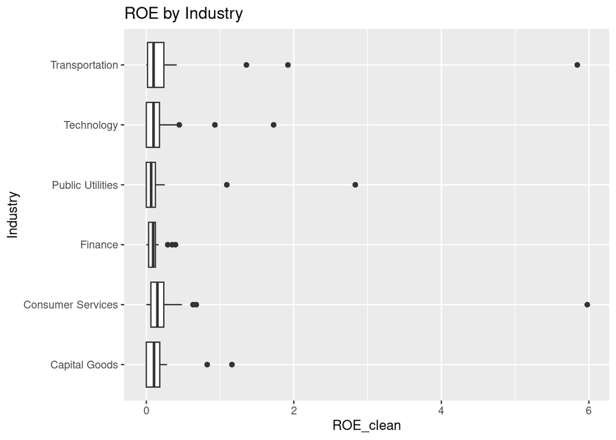

```r
duPont_2015 <- duPont %>% filter(Year == 2015)

ggplot(duPont_2015, aes(x = Industry, y = ROE_clean)) +
  geom_boxplot() + coord_flip() + ggtitle("ROE by Industry")
```

**Question 01, Student**

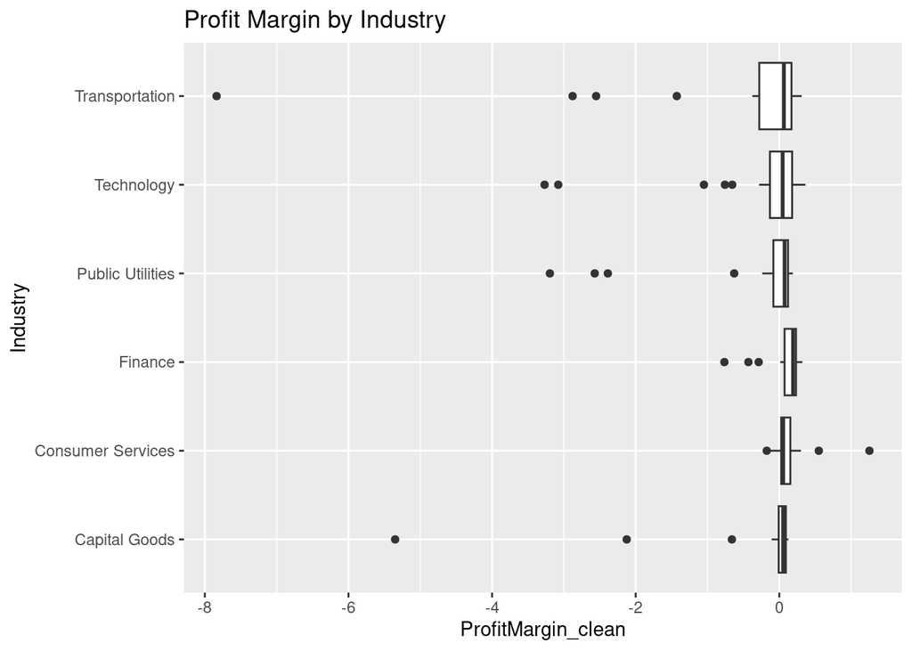

```r
ggplot(duPont_2015, aes(x = Industry, y = ProfitMargin_clean)) +
  geom_boxplot() + coord_flip() + ggtitle("Profit Margin by Industry")
```

**Question 01, Student**

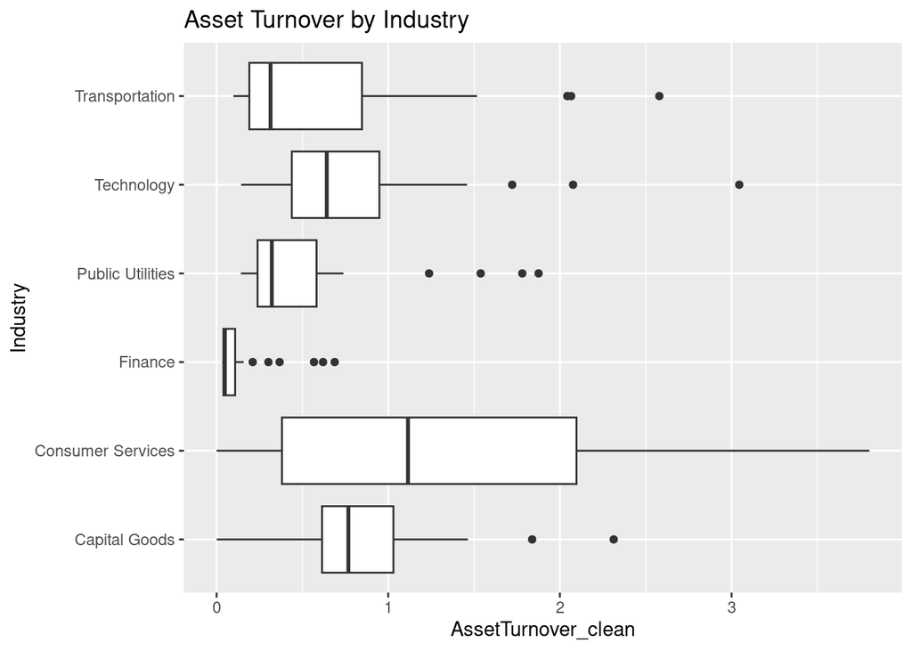

```r
ggplot(duPont_2015, aes(x = Industry, y = AssetTurnover_clean)) +
  geom_boxplot() + coord_flip() + ggtitle("Asset Turnover by Industry")
```

**Question 01, Student**

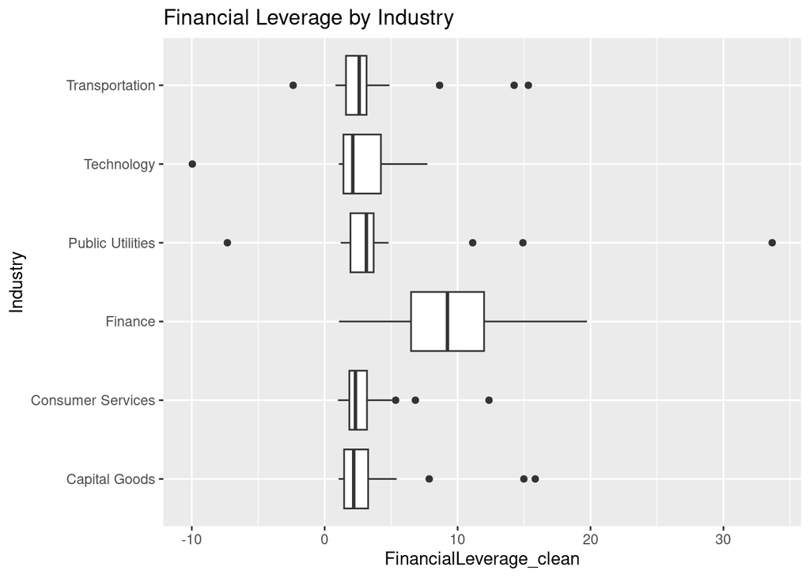

```r
ggplot(duPont_2015, aes(x = Industry, y = FinancialLeverage_clean)) +
  geom_boxplot() + coord_flip() + ggtitle("Financial Leverage by Industry")
```

**Analysis follow up:** Looking back at your answers in part II, were these results in line with your industry expectations?

2. Which industry has seen the greatest improvement in ROE from 2013 to 2015? Consider both the mean and median trends from 2013 to 2015. Create a chart to show the ROE for each industry over time.

**Question 02, Student**

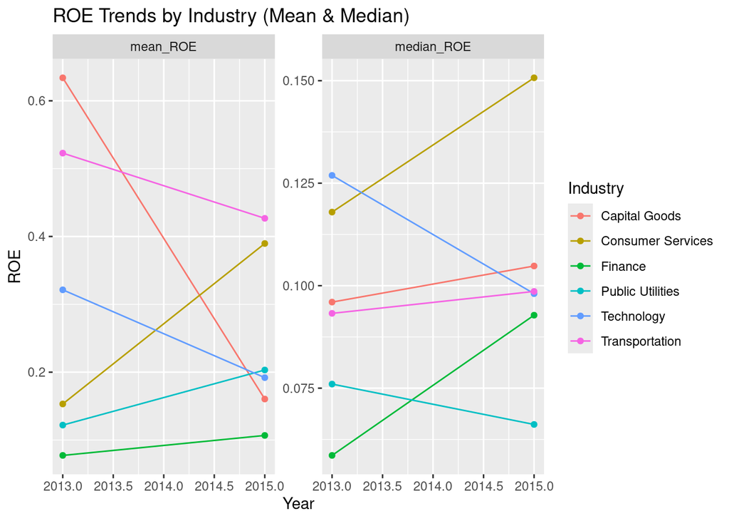

```r
library(tidyr)

duPont %>%
  filter(Year %in% c(2013, 2015)) %>%
  group_by(Industry, Year) %>%
  summarise(
    mean_ROE = mean(ROE_clean, na.rm = TRUE),
    median_ROE = median(ROE_clean, na.rm = TRUE),
    .groups = "drop"
  ) %>%
  pivot_longer(cols = c(mean_ROE, median_ROE), names_to = "Metric", values_to = "ROE") %>%
  ggplot(aes(x = Year, y = ROE, color = Industry)) +
  geom_line() + geom_point() +
  facet_wrap(~Metric, scales = "free_y") +
  labs(title = "ROE Trends by Industry (Mean & Median)", y = "ROE", x = "Year")
```

**Analysis follow up:** How many industries have an improvment between 2013 & 2015.

Between 2013 and 2015, two industries—Consumer Services and Finance—showed a consistent improvement in both mean and median Return on Equity (ROE). This indicates a robust and steady enhancement in financial performance across companies within these sectors.

**Questions about individual companies**

3. What companies have the best ROE within each industry for 2015? Sort the data so you can see the companies listed from highest to lowest ROE. Make a sorted horizontal barchart to show your answer.

**Question 03, Student**

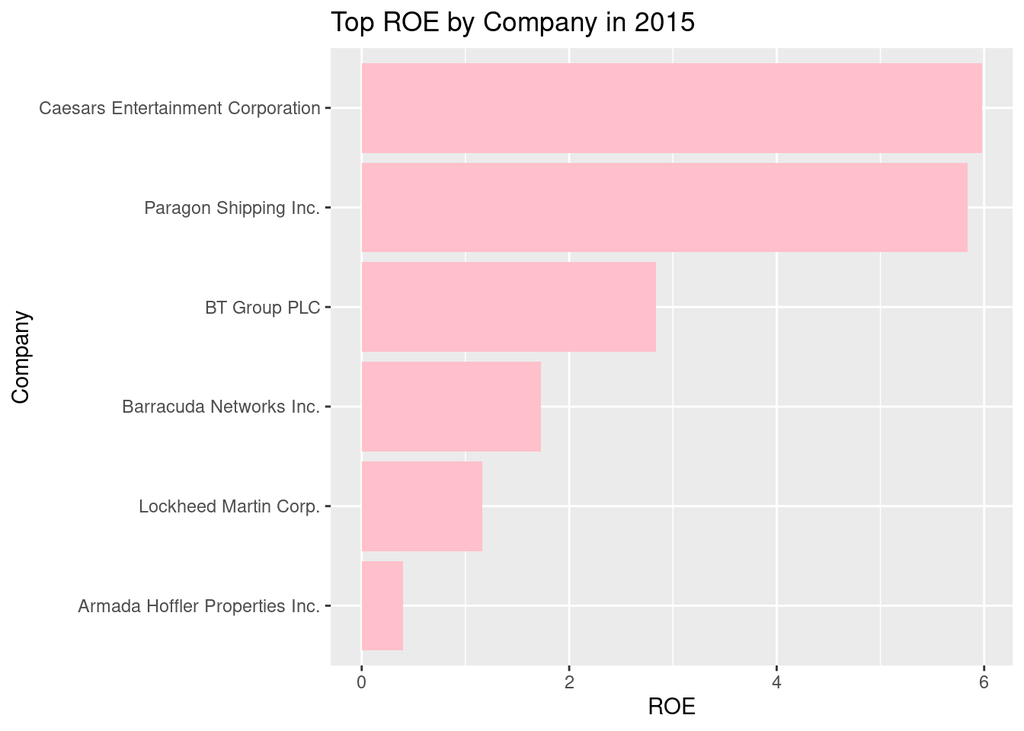

```r
top_roe_2015 <- duPont %>%
  filter(Year == 2015) %>%
  group_by(Industry) %>%
  filter(ROE_clean == max(ROE_clean, na.rm = TRUE)) %>%
  ungroup() %>%
  arrange(desc(ROE_clean))

ggplot(top_roe_2015, aes(x = reorder(Name, ROE_clean), y = ROE_clean)) +
  geom_col(fill = "pink") +
  coord_flip() +
  labs(title = "Top ROE by Company in 2015", x = "Company", y = "ROE")
```

**Analysis follow up:** What is the company has the best ROE for 2015 within `Public Utilities`

4. Companies that have negative profit margins but are increasing their asset turnover ratio are “accelerating into a brick wall” (i.e., they are getting better at losing money). What companies in 2015 are the worst in that they have a negative profit margin and the highest asset turnover ratio? Create a chart to show your answer.

**Question 04, Student**

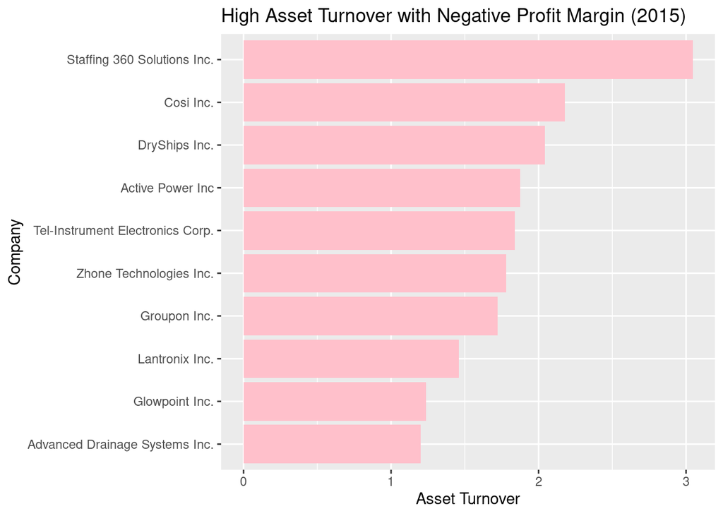

```r
duPont %>%
  filter(Year == 2015, ProfitMargin_clean < 0) %>%
  arrange(desc(AssetTurnover_clean)) %>%
  head(10) %>%
  ggplot(aes(x = reorder(Name, AssetTurnover_clean), y = AssetTurnover_clean)) +
  geom_col(fill = "pink") +
  coord_flip() +
  labs(title = "High Asset Turnover with Negative Profit Margin (2015)",
       y = "Asset Turnover", x = "Company")
```

**Analysis follow up:** What is the top ranked company within `Transportation` that has this concern?

**STUDENT RESPONSE REQUIRED**  
DryShips Inc.is the top ranked company within `Transportation` that has this concern of having negative profit margins but are increasing their asset turnover ratio.

5. Select one of your questions your asked from Part II and answer it. It should be not be a significant overlap to the above questions. Please copy the question below and answer in the code chunk.

Question Selected from Part II:How many **different** companies are there in each industry? Is the largest industry by count the largest industry by shareholder equity in 2015?

**Question 05, Student**

```r
# A: Count distinct companies in each industry
company_count <- duPont %>%
  select(Industry, Name) %>%
  distinct() %>%
  count(Industry, name = "Company_Count") %>%
  arrange(desc(Company_Count))

# B: Total shareholder equity by industry in 2015
equity_2015 <- duPont %>%
  filter(Year == 2015) %>%
  group_by(Industry) %>%
  summarise(Total_Shareholder_Equity = sum(ShareholderEquity, na.rm = TRUE),
            .groups = "drop") %>%
  arrange(desc(Total_Shareholder_Equity))

# Display side by side (optional if using gt or similar)
left_join(company_count, equity_2015, by = "Industry") %>% gt()
```

| Industry | Company_Count | Total_Shareholder_Equity |
| --- | --- | --- |
| Technology | 30 | 6.326359e+11 |
| Capital Goods | 29 | 3.231155e+11 |
| Finance | 29 | 1.337688e+12 |
| Public Utilities | 29 | 4.920406e+11 |
| Transportation | 29 | 1.081689e+11 |
| Consumer Services | 28 | 2.448514e+11 |

**Analysis follow up:** Student selected…

**STUDENT RESPONSE REQUIRED**  
While Technology has the highest number of companies in the dataset with 30 firms, it is not the industry with the highest total shareholder equity. That distinction goes to Finance, which, despite having only 29 companies, reports the largest total shareholder equity at over $1.3 trillion. This contrast suggests that companies in the Finance sector tend to operate with significantly larger equity bases — such as major banks and financial institutions — compared to industries like Technology or Consumer Services. Overall, this outcome aligns with expectations: financial firms often manage vast capital reserves and assets, which inflates their equity figures, even if their representation in the dataset is similar to other industries.

## Session Info

```r
date()
```

```
[1] "Mon Mar 31 03:41:37 2025"
```

```r
Sys.getenv()
```

[output not shown]

[output cut: 78 more lines]

[output not shown]